# K-Means Clustering

```r
library(janitor)
```

```r
edu_data <- read_csv("data/school_data.csv")
```

```r
edu_data <- edu_data %>%
  column_to_rownames("X1") %>%
  clean_names()

edu_data
```

|  | home_school | state_school | urban_pop | private_school |
| --- | --- | --- | --- | --- |
| Alabama | 1320 | 23600 | 5800 | 2120 |
| Alaska | 1000 | 26300 | 4800 | 4450 |
| Arizona | 810 | 29400 | 8000 | 3100 |
| Arkansas | 880 | 19000 | 5000 | 1950 |
| California | 900 | 27600 | 9100 | 4060 |
| Colorado | 790 | 20400 | 7800 | 3870 |
| Connecticut | 330 | 11000 | 7700 | 1110 |
| Delaware | 590 | 23800 | 7200 | 1580 |
| Florida | 1540 | 33500 | 8000 | 3190 |
| Georgia | 1740 | 21100 | 6000 | 2580 |

[output cut: 40 more lines]

```r
edu_data <- edu_data  %>%
              select(c(home_school, state_school))

head(edu_data)
```

|  | home_school | state_school |
| --- | --- | --- |
| Alabama | 1320 | 23600 |
| Alaska | 1000 | 26300 |
| Arizona | 810 | 29400 |
| Arkansas | 880 | 19000 |
| California | 900 | 27600 |
| Colorado | 790 | 20400 |

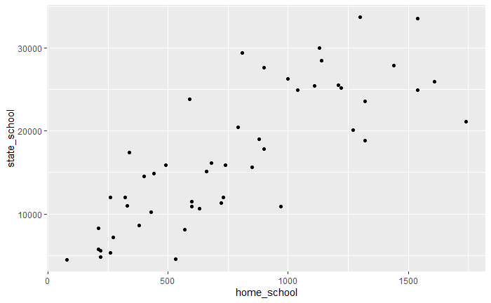

```r
edu_data %>%
ggplot(aes(x = home_school, y = state_school)) +
  geom_point()
```

```r
edu_data %>%
  as_tibble() %>%
  pivot_longer(cols = c(home_school, state_school),
               names_to = "type",
               values_to = "value") %>% #convert data to long format
  group_by(type)%>%
  summarise(mean = round(mean(value)),
            sd = sd(value))
```

| type | mean | sd |
| --- | --- | --- |
| home_school | 779 | 435.551 |
| state_school | 17076 | 8333.766 |

Task - 5 mins Scale the data! (via creating a new dataframe called edu_scale)

```r
edu_scale <- edu_data %>%
              mutate_if(is.numeric, scale)

edu_scale <- edu_data %>%   # dose the same but is more up todate
              mutate(across(where(is.numeric), scale))

edu_scale
```

|  | home_school | state_school |
| --- | --- | --- |
| Alabama | 1.24256408 | 0.78283935 |
| Alaska | 0.50786248 | 1.10682252 |
| Arizona | 0.07163341 | 1.47880321 |
| Arkansas | 0.23234938 | 0.23086801 |
| California | 0.27826823 | 1.26281442 |
| Colorado | 0.02571456 | 0.39885929 |
| Connecticut | -1.03041900 | -0.72908214 |
| Delaware | -0.43347395 | 0.80683810 |
| Florida | 1.74767144 | 1.97077766 |
| Georgia | 2.20685994 | 0.48285493 |

[output cut: 40 more lines]

```r
edu_scale %>%
  as_tibble() %>%
  pivot_longer(cols = c(home_school, state_school),
               names_to = "type",
               values_to = "value") %>% #convert data to long format
  group_by(type)%>%
  summarise(mean = round(mean(value)),
            sd = sd(value))
```

| type | mean | sd |
| --- | --- | --- |
| home_school | 0 | 1 |
| state_school | 0 | 1 |

```r
set.seed(1234)

clustered_edu <- kmeans(edu_scale,
                        centers = 6,
                        nstart = 25)

clustered_edu
```

```
K-means clustering with 6 clusters of sizes 8, 8, 10, 9, 7, 8

Cluster means:
  home_school state_school
1  1.59269532    0.8878339
2 -0.92423166   -0.4305976
3  0.70531354    1.2688141
4 -1.18093078   -1.3210514
5 -0.20715961   -0.7582235
6 -0.04029379    0.1063745

Clustering vector:
       Alabama         Alaska        Arizona       Arkansas     California       Colorado    Connecticut       Delaware
             1              3              3              6              3              6              2              6
       Florida        Georgia         Hawaii          Idaho       Illinois        Indiana           Iowa         Kansas
             1              1              4              2              3              5              4              5
      Kentucky      Louisiana          Maine       Maryland  Massachusetts       Michigan      Minnesota    Mississippi
             5              1              4              3              2              3              4              1
      Missouri        Montana       Nebraska         Nevada  New Hampshire     New Jersey     New Mexico       New York
             6              5              2              3              4              6              3              3
North Carolina   North Dakota           Ohio       Oklahoma         Oregon   Pennsylvania   Rhode Island South Carolina
             3              4              5              6              2              5              2              1
  South Dakota      Tennessee          Texas           Utah        Vermont       Virginia     Washington  West Virginia
             4              1              1              2              4              6              2              5
     Wisconsin        Wyoming
             4              6

Within cluster sum of squares by cluster:
[1] 3.2796553 0.8700729 2.1018616 0.9594623 0.7436899 1.3691194
 (between_SS / total_SS =  90.5 %)

Available components:

[1] "cluster"      "centers"      "totss"        "withinss"     "tot.withinss" "betweenss"    "size"         "iter"
[9] "ifault"
```

```r
library(broom)
library(tidyverse)
```

```r
tidy(clustered_edu,
     col.names = colnames(edu_scale))
```

| home_school | state_school | size | withinss | cluster |
| --- | --- | --- | --- | --- |
| 1.59269532 | 0.8878339 | 8 | 3.2796553 | 1 |
| -0.92423166 | -0.4305976 | 8 | 0.8700729 | 2 |
| 0.70531354 | 1.2688141 | 10 | 2.1018616 | 3 |
| -1.18093078 | -1.3210514 | 9 | 0.9594623 | 4 |
| -0.20715961 | -0.7582235 | 7 | 0.7436899 | 5 |
| -0.04029379 | 0.1063745 | 8 | 1.3691194 | 6 |

```r
augment(clustered_edu, edu_data)
```

| .rownames | home_school | state_school | .cluster |
| --- | --- | --- | --- |
| Alabama | 1320 | 23600 | 1 |
| Alaska | 1000 | 26300 | 3 |
| Arizona | 810 | 29400 | 3 |
| Arkansas | 880 | 19000 | 6 |
| California | 900 | 27600 | 3 |
| Colorado | 790 | 20400 | 6 |
| Connecticut | 330 | 11000 | 2 |
| Delaware | 590 | 23800 | 6 |
| Florida | 1540 | 33500 | 1 |
| Georgia | 1740 | 21100 | 1 |

[output cut: 40 more lines]

```r
glance(clustered_edu)
```

| totss | tot.withinss | betweenss | iter |
| --- | --- | --- | --- |
| 98 | 9.323861 | 88.67614 | 2 |

From this, we get the following metrics:

- **totss:** total sum of squares.
- **withinss:** vector of within-cluster sum of squares, one component per cluster (not in this output but can extract from clusters)
- **tot.withinss:** total within-cluster sum of squares, i.e. sum(withinss).
- **betweenss:** the between-cluster sum of squares, i.e. totss−tot.withinss.
- **iter:** number of iterations until stopped.

```r
clustered_edu$totss
```

```
[1] 98
```

> When choosing our number of clusters, we are looking to minimise the variation within the clusters (so in turn increasing the between cluster variation). Within cluster variation measures how compact the clusters are : we want less variation. However there is a trade off - to get the lowest within cluster variation would be a single data point per cluster i.e. as many clusters as there is data points and there then would be zero variation within cluster! But this would be overfitting. So there is a balance. Let’s discuss how we use the total within-cluster sum of squares to find to optimum number of clusters.

## Gathering your cluster information

```r
# Set min & max number of clusters want to look at
max_k <- 20

k_clusters <- tibble(k = 1:max_k) %>%
  mutate(
    kclust = map(k, ~ kmeans(edu_scale, .x, nstart = 25)),
    tidied = map(kclust, tidy),
    glanced = map(kclust, glance),
    augmented = map(kclust, augment, edu_data)
  )

k_clusters
```

| k | kclust | tidied | glanced | augmented |
| --- | --- | --- | --- | --- |
| 1 |  |  |  |  |
| 2 |  |  |  |  |
| 3 |  |  |  |  |
| 4 |  |  |  |  |
| 5 |  |  |  |  |
| 6 |  |  |  |  |
| 7 |  |  |  |  |
| 8 |  |  |  |  |
| 9 |  |  |  |  |
| 10 |  |  |  |  |

[output cut: 10 more lines]

```r
k_clusters %>%
  select(1,5) %>%
  unnest()
```

| k | .rownames | home_school | state_school | .cluster |
| --- | --- | --- | --- | --- |
| 1 | Alabama | 1320 | 23600 | 1 |
| 1 | Alaska | 1000 | 26300 | 1 |
| 1 | Arizona | 810 | 29400 | 1 |
| 1 | Arkansas | 880 | 19000 | 1 |
| 1 | California | 900 | 27600 | 1 |
| 1 | Colorado | 790 | 20400 | 1 |
| 1 | Connecticut | 330 | 11000 | 1 |
| 1 | Delaware | 590 | 23800 | 1 |
| 1 | Florida | 1540 | 33500 | 1 |
| 1 | Georgia | 1740 | 21100 | 1 |

[output cut: 990 more lines]

## Choosing the number of clusters

#### Method 1 - Elbow method

```r
clusterings <- k_clusters %>%
  unnest(glanced)

clusterings
```

| k | kclust | tidied | totss | tot.withinss | betweenss | iter | augmented |
| --- | --- | --- | --- | --- | --- | --- | --- |
| 1 |  |  | 98 | 98.000000 | 0.00000 | 1 |  |
| 2 |  |  | 98 | 28.989438 | 69.01056 | 1 |  |
| 3 |  |  | 98 | 18.217665 | 79.78233 | 2 |  |
| 4 |  |  | 98 | 14.072811 | 83.92719 | 2 |  |
| 5 |  |  | 98 | 11.326651 | 86.67335 | 3 |  |
| 6 |  |  | 98 | 9.193923 | 88.80608 | 2 |  |
| 7 |  |  | 98 | 7.191133 | 90.80887 | 3 |  |
| 8 |  |  | 98 | 6.119187 | 91.88081 | 5 |  |
| 9 |  |  | 98 | 5.185396 | 92.81460 | 3 |  |
| 10 |  |  | 98 | 4.470061 | 93.52994 | 4 |  |

[output cut: 10 more lines]

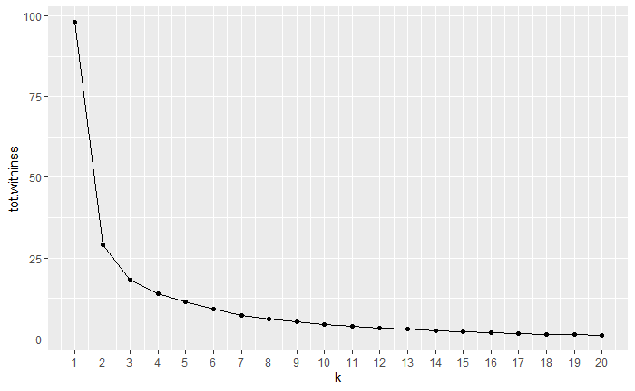

```r
ggplot(clusterings, aes(x=k, y=tot.withinss)) +
  geom_point() +
    geom_line() +
    scale_x_continuous(breaks = seq(1, 20, by = 1))
```

```r
library(factoextra)
```

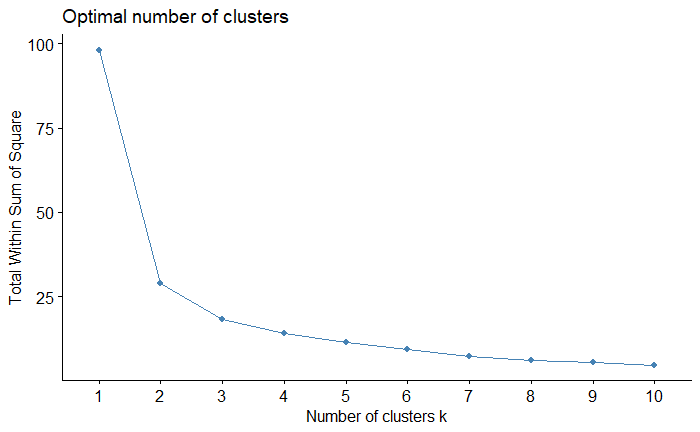

```r
fviz_nbclust(edu_scale,
             kmeans,
             method = "wss",
             nstart = 25)
```

#### Method 2 - Silhouette coefficient

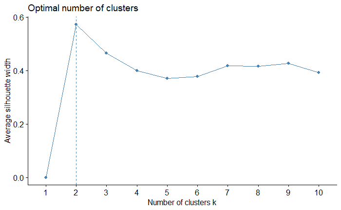

```r
fviz_nbclust(edu_scale,
             kmeans,
             method = "silhouette",
             nstart = 25)
```

#### Method 3 - Gap statistic

```
Clustering k = 1,2,..., K.max (= 10): .. done
Bootstrapping, b = 1,2,..., B (= 100)  [one "." per sample]:
.................................................. 50
.................................................. 100
```

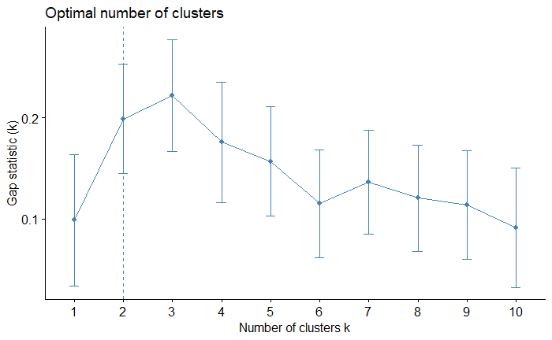

```r
fviz_nbclust(edu_scale,
             kmeans,
             method = "gap_stat",
             nstart = 25,
             k.max = 10)
```

Note each of these methods can also be used for hierarchical clustering you just replace the kmeans argument in fviz_nbclust with FUN = hcut.

```
Clustering k = 1,2,..., K.max (= 10): .. done
Bootstrapping, b = 1,2,..., B (= 100)  [one "." per sample]:
.................................................. 50
.................................................. 100
```

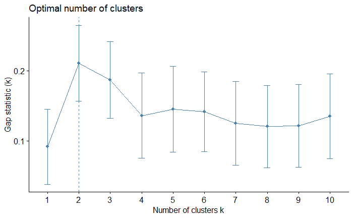

```r
fviz_nbclust(edu_scale,
             hcut,
             method = "gap_stat",
             nstart = 25,
             k.max = 10)
```

## Now we have chosen value of k

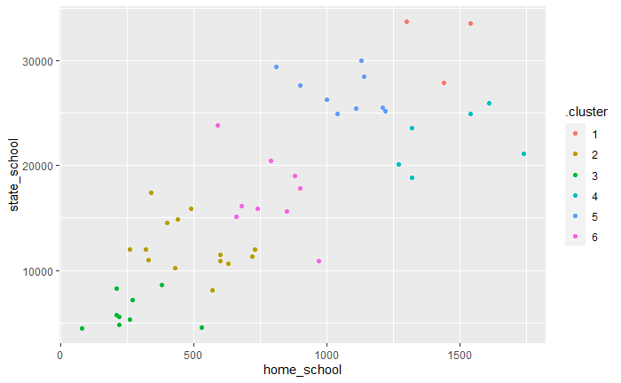

```r
clusterings %>%
  unnest(cols = c(augmented)) %>%
  filter(k <= 6) %>%
  ggplot(aes(x = home_school, y = state_school)) +
  geom_point(aes(color = .cluster))
```

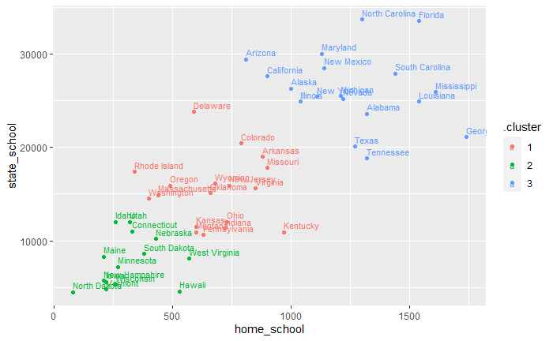

```r
clusterings %>%
  unnest(cols = c(augmented)) %>%
  filter(k == 3) %>%
 ggplot(aes(x = home_school, y = state_school, colour = .cluster, label = .rownames)) +
  geom_point(aes(color = .cluster)) +
  geom_text(hjust = 0, vjust = - 0.5, size = 3)
```